# London Bike Sharing Data Exploration

## by Beijia(Frances) Yu

## Investigation Overview

> I selected bike sharing dataset in order to investigate bike hiring by people. There are a lot of different variables and the main focus is to find out how these variables will affect the bike hiring on the project.

## Dataset Overview

> In this dataset, it contains 17414 records. It includes the following data types: string, integer, float and boolean. Some variables describe the weather condition: real_temperature, humidity as well as wind_speed. Some are about when the sharing was happening: timestamp, is_holiday, is_weekend, season_code, date, year, season.

## The Distribution of Weather Conditions

> - Among 17414 records in the dataset, over 6000 records are associated with clear weather. More than 7500 bike sharings was done in cloudy days.
> - In other words, sharing bikes is most popular, at least 77.5%, when the weather is nice

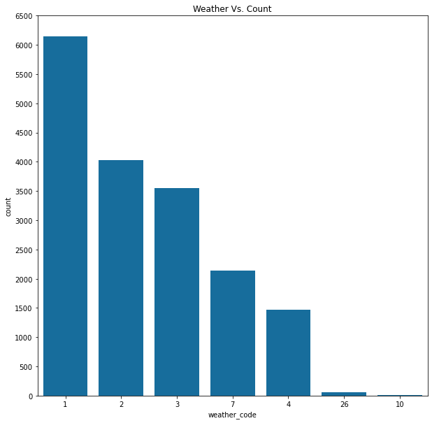

```python
plt.rcParams['figure.figsize'] = (10, 10)

y_pos = np.arange(0, 6500+500, 500)

sns.countplot(
    x='weather_code',
    data=df_tmp,
    order=df_tmp['weather_code'].value_counts().index,
    color=base_color
)

plt.yticks(y_pos)

plt.title('Weather Vs. Count')

plt.show()
```

## Weather Condition & Shared Counts

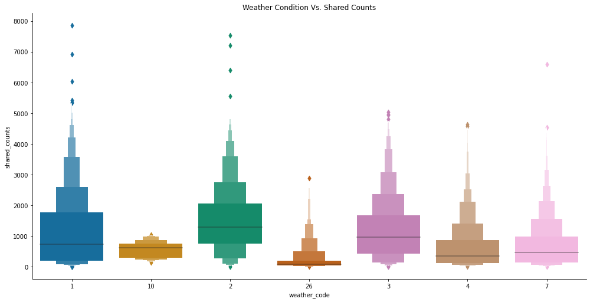

```python
sns.catplot(
    x='weather_code',
    y='shared_counts',
    data=df_tmp,
    kind='boxen',
    palette=current_palette,
    height=7,
    aspect=2
)

plt.title('Weather Condition Vs. Shared Counts')

plt.show()
```

## Weather Condition, Shared Counts, Is Weekend & Season

> - Most of the time, people uses shared bikes more often on weekdays than on weekends.
> - In certain circumstances, like in certain season or certain weather condition, people do use shared bikes on weekends more often than on weekdays.

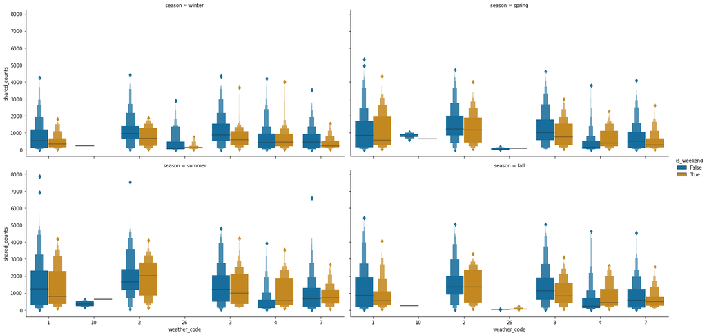

```python
sns.catplot(
    x='weather_code',
    y='shared_counts',
    data=df_tmp,
    kind='boxen',
    col='season',
    palette=current_palette,
    hue='is_weekend',
    col_wrap=2,
    height=5,
    aspect=2
)

plt.show()
```

## Effects of Weather Conditions on Bike Sharings

> - All of temperature, humidity, wind speed can have an impact on bike sharings.
> - In addition, each of them results in different distributions of bike sharings as we can see from the following plots

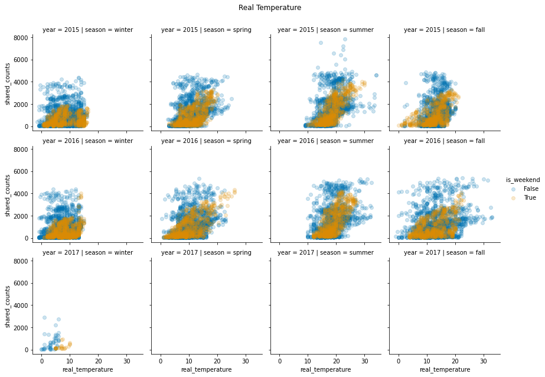

```python
g = sns.FacetGrid(df, row='year', col='season', hue='is_weekend')
g = g.map(plt.scatter, 'real_temperature', 'shared_counts', alpha = 0.2).add_legend()
g.fig.suptitle('Real Temperature')
g.fig.subplots_adjust(top=0.9)
```

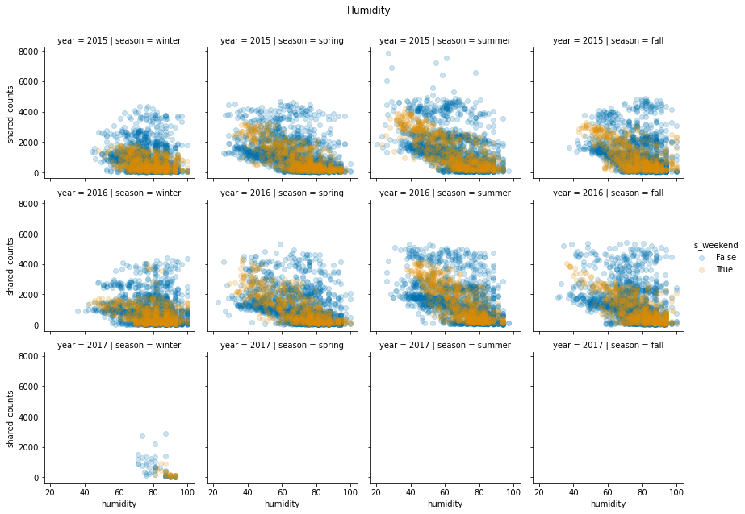

```python
g = sns.FacetGrid(df_tmp, row='year', col='season', hue='is_weekend')
g = g.map(plt.scatter, 'humidity', 'shared_counts', alpha = 0.2).add_legend()
g.fig.suptitle('Humidity')
g.fig.subplots_adjust(top=0.9)
```

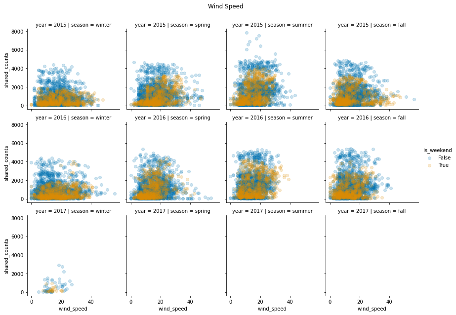

```python
g = sns.FacetGrid(df_tmp, row='year', col='season', hue='is_weekend')
g = g.map(plt.scatter, 'wind_speed', 'shared_counts', alpha = 0.2).add_legend()
g.fig.suptitle('Wind Speed')
g.fig.subplots_adjust(top=0.9)
```

```python
!! jupyter nbconvert slide_deck_1.ipynb --to slides --post serve --template output_toggle
```